# Day 1

Andy Teucher

November 20, 2014

```r
library(dplyr)
```

```r
library(ggplot2)
library(scales)
library(jaggernaut)
options(digits = 4)
```

## Exercise 1

Prior information told us it is *definitely* biased towards tails:

```r
model1 <- jags_model("
  model {
    theta ~ dunif(0,0.5)
    y ~ dbin(theta, n)
  }")
```

By specifying the prior distribution as bounded by (0, 0.5), it means that the final estimate of theta has to be less than 0.5, i.e., the probability of throwing a head is less than 0.5.

```r
data <- data.frame(n = 10, y = 3) # 10 trials, 3 tails
analysis1 <- jags_analysis(model1, data = data)
```

```
## Analysis converged (rhat:1.01)
```

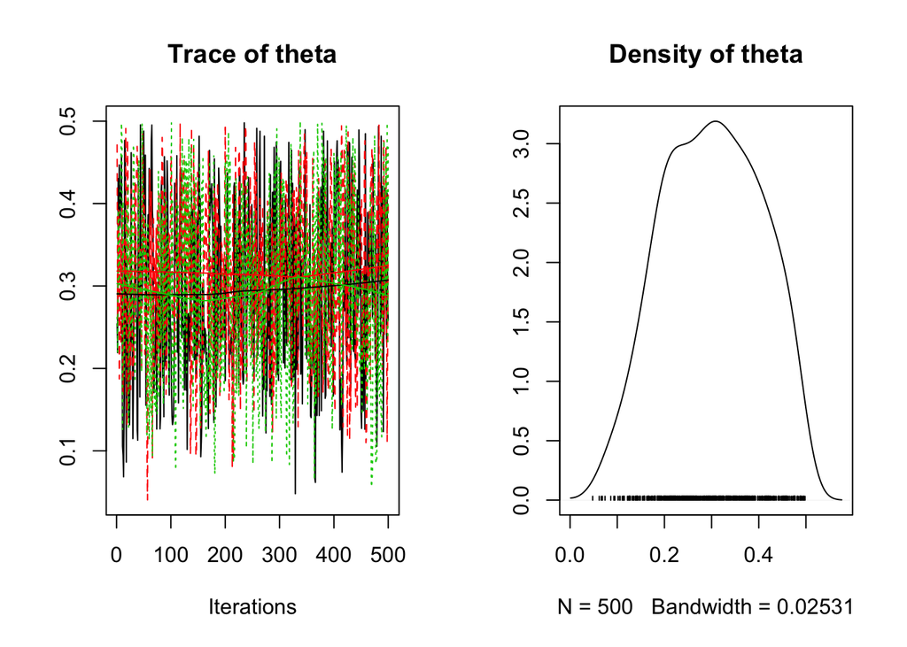

```r
plot(analysis1)
```

```r
coef(analysis1)
```

```
##       estimate  lower  upper     sd error significance
## theta   0.3012 0.1056 0.4801 0.1031    62            0
```

## Black Cherry Trees

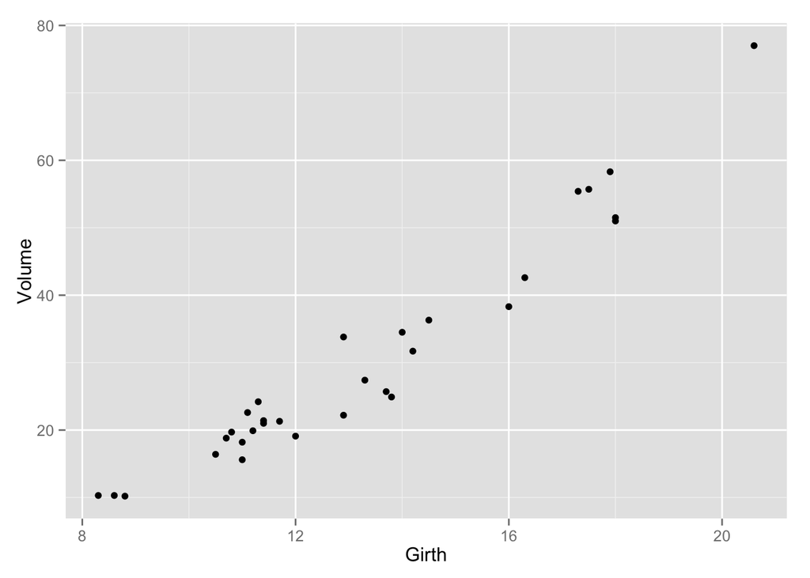

```r
data(trees)
ggplot(trees, aes(x = Girth, y = Volume)) + geom_point()
```

#### To set up parallel processing (one for each chain), run the following code:

```r
if (getDoParWorkers() == 1) {
  registerDoParallel(4)
  opts_jagr(parallel = TRUE)
}
```

```r
tree_model <- jags_model("
model {
  alpha ~ dnorm(0, 50^-2)
  beta ~ dnorm(0, 50^-2)
  sigma ~ dunif(0, 10)

  for (i in 1:length(Volume)) {
    eMu[i] <- alpha + beta * Girth[i]
    Volume[i] ~ dnorm(eMu[i], sigma^-2)
  }
}")

trees_analysis <- jags_analysis(tree_model, data = trees)
```

```
## Analysis converged (rhat:1.04)
```

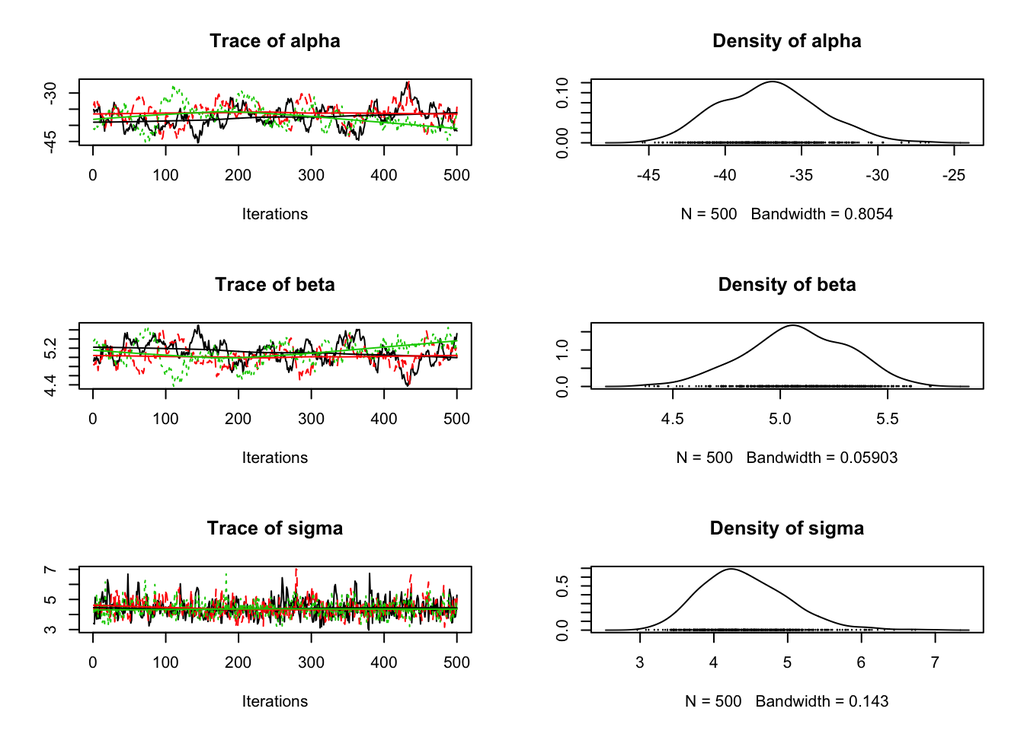

```r
plot(trees_analysis)
```

```r
coef(trees_analysis)
```

```
##       estimate   lower   upper     sd error significance
## alpha  -37.094 -43.013 -30.381 3.2806    17            0
## beta     5.079   4.596   5.518 0.2404     9            0
## sigma    4.419   3.446   5.711 0.5951    26            0
```

## Exercise 2:

```r
auto_corr(trees_analysis)
```

```
##          alpha     beta     sigma
## Lag 1   0.9368  0.93552  0.302001
## Lag 5   0.7006  0.70088  0.003873
## Lag 10  0.4465  0.44415 -0.006799
## Lag 50 -0.0937 -0.09772  0.012155
```

```r
cross_corr(trees_analysis)
```

```
##          alpha     beta    sigma
## alpha  1.00000 -0.96995  0.03276
## beta  -0.96995  1.00000 -0.02061
## sigma  0.03276 -0.02061  1.00000
```

The plots show “poor chain mixing”

Looking at at the plots and the outputs of auto_corr and cross_corr, ther is high autocorrelation in alpha and beta, and high cross-correlation betweenalpha and beta. The cross-correlation is intuitive because as you move the intercept up or down, the slope responds in the opposite direction. The autocorrelation is caused by the cross-correlation because in each MCMC step, the estimate of one parameter is updated based on the previous estimate of the other parameter, and back and forth…

## Exercise 3:

When `jaggernaut` tests for convergence, it evaluates it using `rhat` of the worst performing parameter.

```r
?convergence
```

```
## starting httpd help server ... done
```

```r
convergence(trees_analysis, combine = FALSE)
```

```
##       convergence
## alpha        1.04
## beta         1.03
## sigma        1.00
```

```r
# Can get just specific parameters:
convergence(trees_analysis, parm = c("alpha", "beta"), combine = FALSE)
```

```
##       convergence
## alpha        1.04
## beta         1.03
```

Run `opts_jagr()` to see the jaggernaut options. Set with `opts_jagr(option = value)` (e.g., `opts_jagr(mode = "paper")` or `opts_jagr(nsamples = 5000)`).

## Exercise 4:

To run more iterations (e.g., to get better convergence):

```r
trees_analysis <- jags_analysis(tree_model, data = trees, niter = 10^4)
```

```
## Analysis converged (rhat:1.01)
```

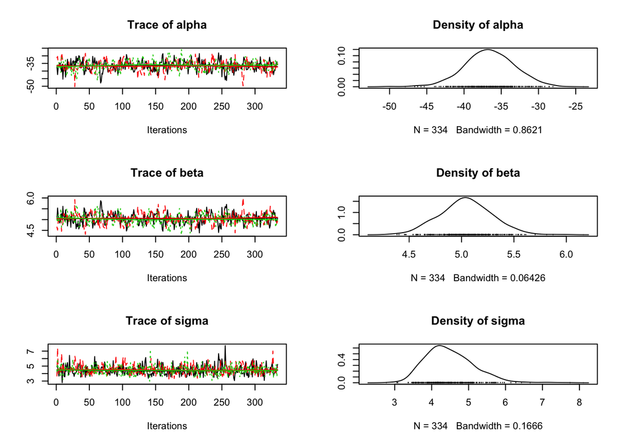

```r
plot(trees_analysis)
```

```r
coef(trees_analysis)
```

```
##       estimate   lower   upper     sd error significance
## alpha  -36.573 -43.147 -30.016 3.3695    18            0
## beta     5.041   4.564   5.519 0.2497     9            0
## sigma    4.486   3.486   5.882 0.6509    27            0
```

```r
convergence(trees_analysis, combine = FALSE)
```

```
##       convergence
## alpha        1.01
## beta         1.01
## sigma        1.00
```

If you center the intercept on the x variable (girth), it will break the cross-correlation between the slope and intercept because you can now change the slope without affecting the intercept, and vice-versa.

## Exercise 5:

```r
## Option 1 Transform the variable:
tree_model <- jags_model("
model {
  alpha ~ dnorm(0, 50^-2)
  beta ~ dnorm(0, 50^-2)
  sigma ~ dunif(0, 10)

  for (i in 1:length(Volume)) {
    eMu[i] <- alpha + beta * Girth[i]
    Volume[i] ~ dnorm(eMu[i], sigma^-2)
  }
}")

trees$Girth <- trees$Girth - mean(trees$Girth)

trees_analysis <- jags_analysis(tree_model, data = trees)
```

```
## Analysis converged (rhat:1)
```

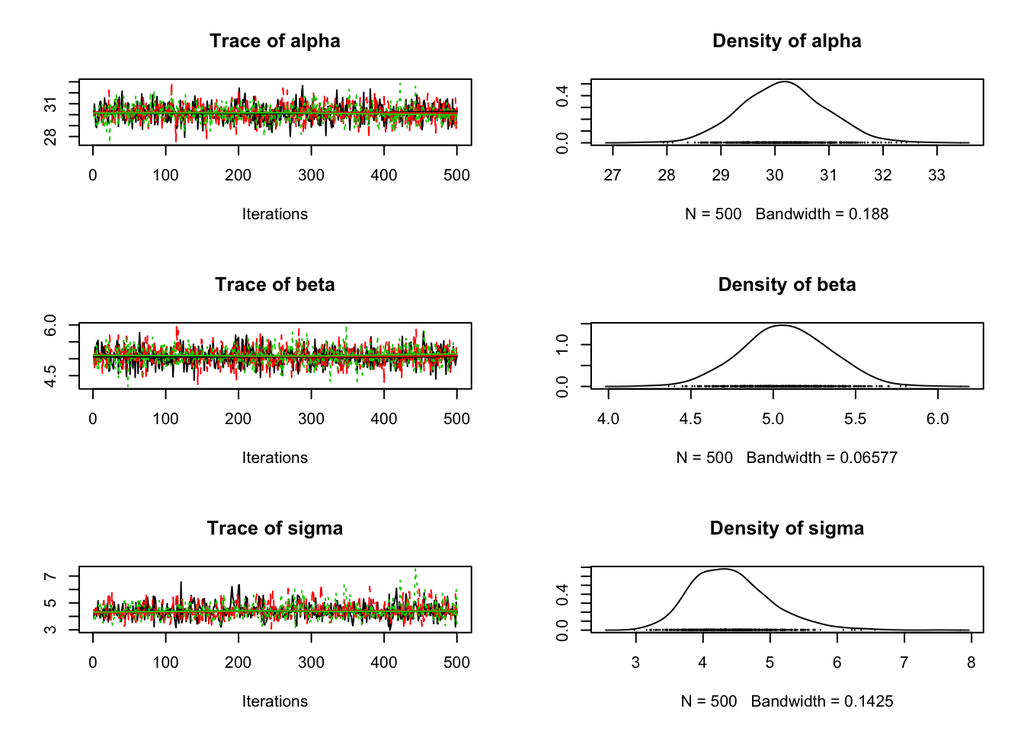

```r
plot(trees_analysis)
```

```r
coef(trees_analysis)
```

```
##       estimate  lower  upper     sd error significance
## alpha   30.163 28.687 31.708 0.7835     5            0
## beta     5.077  4.556  5.590 0.2679    10            0
## sigma    4.421  3.451  5.753 0.5937    26            0
```

```r
auto_corr(trees_analysis)
```

```
##           alpha      beta     sigma
## Lag 1   0.02312  0.005337  0.273993
## Lag 5  -0.01550 -0.055175 -0.028453
## Lag 10 -0.01481 -0.010107  0.026015
## Lag 50  0.01889 -0.022399 -0.001065
```

```r
cross_corr(trees_analysis)
```

```
##          alpha     beta   sigma
## alpha  1.00000 -0.03273 0.02235
## beta  -0.03273  1.00000 0.02279
## sigma  0.02235  0.02279 1.00000
```

```r
data(trees) # Reset trees after changing the Girth column

## Option 2 (in the BUGS code):
tree_model <- jags_model("
model {
  alpha ~ dnorm(0, 50^-2)
  beta ~ dnorm(0, 50^-2)
  sigma ~ dunif(0, 10)

  for (i in 1:length(Volume)) {
    eMu[i] <- alpha + beta * (Girth[i] - mean(Girth))
    Volume[i] ~ dnorm(eMu[i], sigma^-2)
  }
}")

trees_analysis <- jags_analysis(tree_model, data = trees)
```

```
## Analysis converged (rhat:1)
```

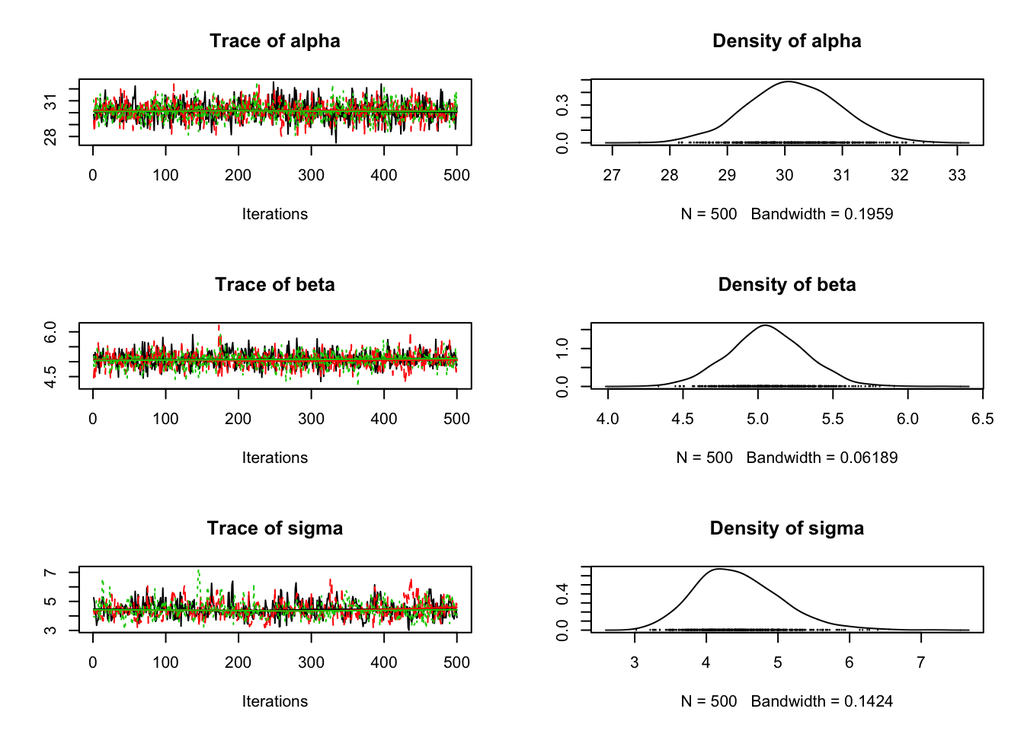

```r
plot(trees_analysis)
```

```r
coef(trees_analysis)
```

```
##       estimate  lower  upper     sd error significance
## alpha   30.150 28.547 31.712 0.7981     5            0
## beta     5.064  4.549  5.566 0.2611    10            0
## sigma    4.444  3.434  5.791 0.5991    27            0
```

```r
auto_corr(trees_analysis)
```

```
##            alpha     beta    sigma
## Lag 1  -0.010410 0.006809  0.36231
## Lag 5  -0.035827 0.008749  0.04166
## Lag 10  0.007524 0.010828  0.04855
## Lag 50 -0.029502 0.022737 -0.01602
```

```r
cross_corr(trees_analysis)
```

```
##           alpha    beta     sigma
## alpha  1.000000 0.04929 -0.005444
## beta   0.049290 1.00000  0.045668
## sigma -0.005444 0.04567  1.000000
```

```r
## Option 3:
tree_model <- jags_model("
model {
  alpha ~ dnorm(0, 50^-2)
  beta ~ dnorm(0, 50^-2)
  sigma ~ dunif(0, 10)

  for (i in 1:length(Volume)) {
    eMu[i] <- alpha + beta * Girth[i]
    Volume[i] ~ dnorm(eMu[i], sigma^-2)
  }
}")

select_data(tree_model) <- c("Volume", "Girth+") # The `+` centers the Girth parameter
trees_analysis <- jags_analysis(tree_model, data = trees)
```

```
## Analysis converged (rhat:1)
```

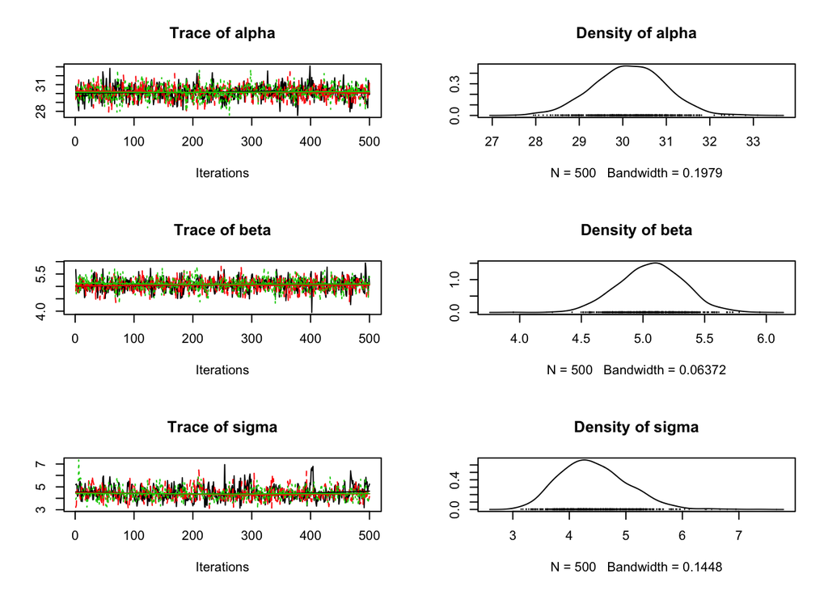

```r
plot(trees_analysis)
```

```r
coef(trees_analysis)
```

```
##       estimate  lower  upper     sd error significance
## alpha   30.146 28.533 31.709 0.8138     5            0
## beta     5.066  4.553  5.577 0.2596    10            0
## sigma    4.430  3.427  5.663 0.5950    25            0
```

```r
auto_corr(trees_analysis)
```

```
##            alpha       beta      sigma
## Lag 1   0.004876 -0.0136166  0.2819304
## Lag 5   0.026424  0.0187835  0.0193164
## Lag 10 -0.016229  0.0566762 -0.0004218
## Lag 50 -0.034328 -0.0008389  0.0056268
```

```r
cross_corr(trees_analysis)
```

```
##          alpha     beta    sigma
## alpha  1.00000  0.03762 -0.01136
## beta   0.03762  1.00000 -0.03356
## sigma -0.01136 -0.03356  1.00000
```

## Exercise 6:

```r
derived_code <- "data {
  for(i in 1:length(Volume)) {
    prediction[i] <- alpha + beta * Girth[i]

    simulated[i] ~ dnorm(prediction[i], sigma^-2)

    D_observed[i] <- log(dnorm(Volume[i], prediction[i], sigma^-2))
    D_simulated[i] <- log(dnorm(simulated[i], prediction[i], sigma^-2))
  }
  residual <- (Volume - prediction) / sigma
  discrepancy <- sum(D_observed) - sum(D_simulated)
}"

predicted <- predict(trees_analysis, newdata = "Girth", derived_code = derived_code)

new.data <- data.frame(Girth = 8)

predicted2 <- predict(trees_analysis, newdata = new.data, derived_code = derived_code)
predicted2
```

```
##   Girth Height Volume estimate  lower upper    sd error significance
## 1     8     76  30.17    3.555 0.4803 6.502 1.561    85        0.016
```

The 95% prediction interval is 0.4803 to 6.5016